# Growth Curve Analysis, Part 2

Dan Mirman

28 November 2019

# Modeling non-linear change over time

- Choosing a functional form
  - Function must be adequate to data
  - Dynamic consistency
  - Prediction
- Higher-order polynomials
- Orthogonal polynomials

# Function must be adequate to data

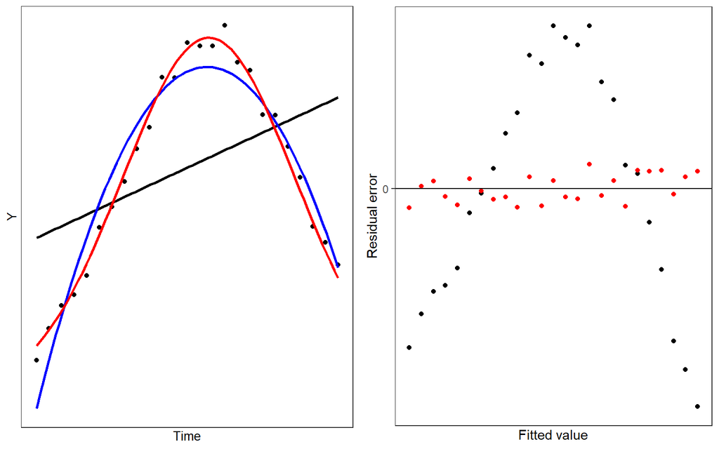

- Easy plotting residuals vs. fitted: `ggplot(fortify(m, dat), aes(.fitted, .resid)) + geom_point()`

# Two kinds of non-linearity

1. Non-linear in variables (Time): $Y_{ij} = \beta_{0i} + \beta_{1i} \cdot Time_{j} + \beta_{2i} \cdot Time^2_{j} + \epsilon_{ij}$
2. Non-linear in parameters (b): $Y = \frac{p-b}{1+exp(4 \cdot \frac{s}{p-b} \cdot (c-t))} + b$
- Dynamic Consistency: The model of the average is equal to the average of the individual models
  - Recall: random effects must have a mean of 0
  - Average of individual deviations is 0
  - So, the average of the individual models will have 0 deviation from the model of the average
  - Not true of some tempting functional forms

# Example of lack of dynamic consistency

Logistic power peak function (Scheepers, Keller, & Lapata, 2008) fit to semantic competition data (Mirman & Magnuson, 2009).

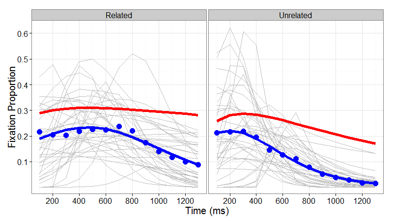

- Standard statistical inference assumes that the group average represents central tendency of individuals
- For dynamically inconsistent models this is not true
- Can’t make inferences about central tendencies without dynamic consistency

# Prediction: Two kinds

**Fits: Statistical models**

- Example: Mean and SD
- Describe the observed data
- No new predictions
- Not falsifiable

**Forecasts: Theoretical models**

- Example: Interactive Activation
- Match the observed data
- Makes new predictions
- Falsifiable

# Using higher-order polynomials

- Can model any curve shape
- Dynamically consistent
- Bad at capturing asymptotic behavior
  - Don’t extrapolate
  - Try to avoid long flat sections
- **How to choose polynomial order?**
  - Curve shape
  - Statistical: include only terms that statistically improve model fit
  - Theoretical: include only terms that are predicted to matter

# Natural vs. Orthogonal polynomials

- Natural Polynomials: Correlated time terms
- Orthogonal Polynomials: Uncorrelated time terms
  - Need to specify range and order

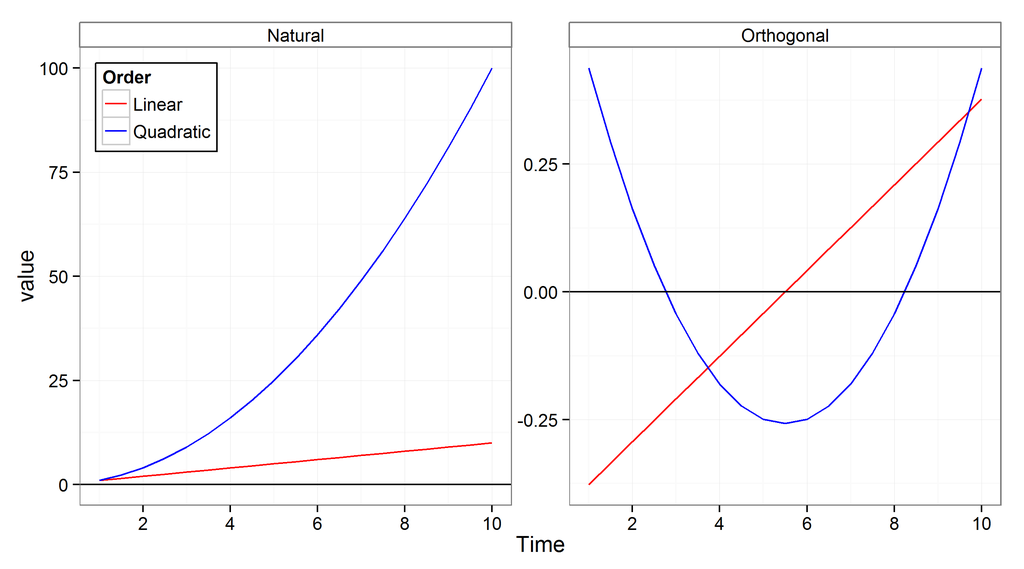

# Interpreting orthogonal polynomial terms

Intercept ($\beta_0$): Overall average

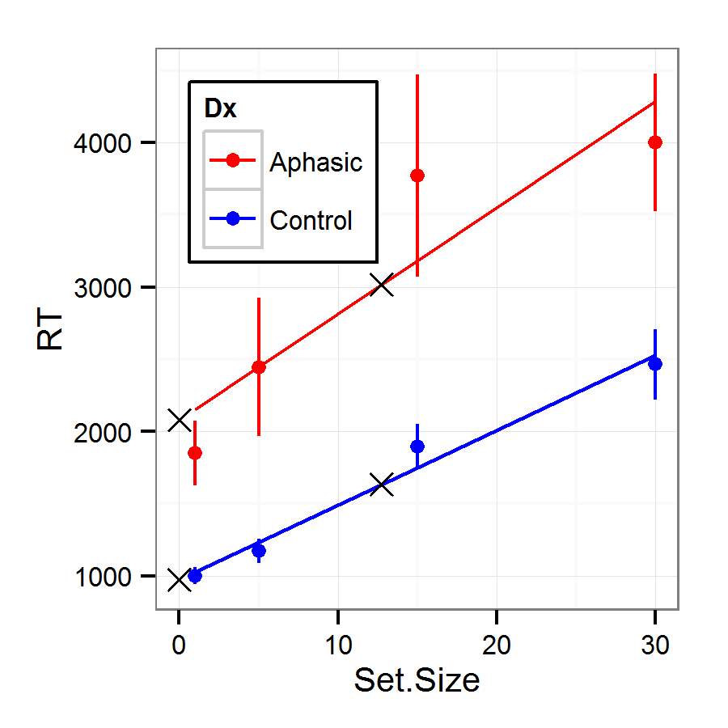

# Interpreting orthogonal polynomial terms

Intercept ($\beta_0$): Overall average

Linear ($\beta_1$): Overall slope

Quadratic ($\beta_2$): Centered rise and fall rate

Cubic, Quartic, … ($\beta_3, \beta_4, ...$): Inflection steepness

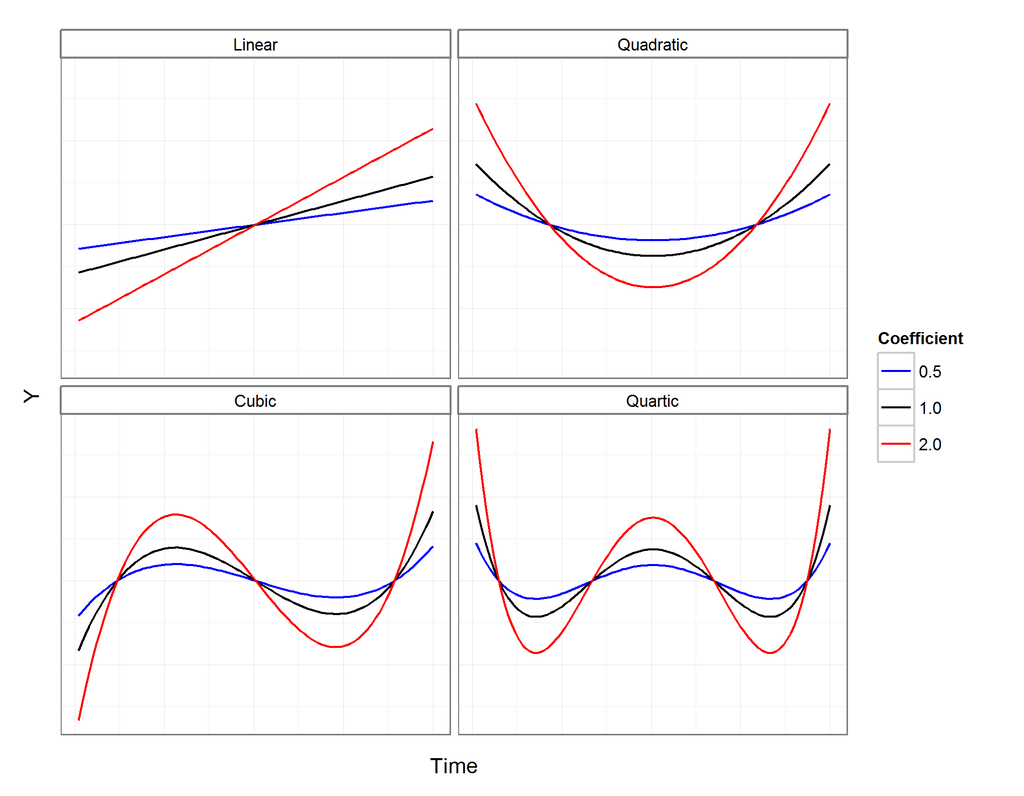

# Example

Effect of transitional probability on word learning

```r
summary(WordLearnEx)
```

```
##     Subject       TP          Block         Accuracy
##  244    : 10   Low :280   Min.   : 1.0   Min.   :0.000
##  253    : 10   High:280   1st Qu.: 3.0   1st Qu.:0.667
##  302    : 10              Median : 5.5   Median :0.833
##  303    : 10              Mean   : 5.5   Mean   :0.805
##  305    : 10              3rd Qu.: 8.0   3rd Qu.:1.000
##  306    : 10              Max.   :10.0   Max.   :1.000
##  (Other):500
```

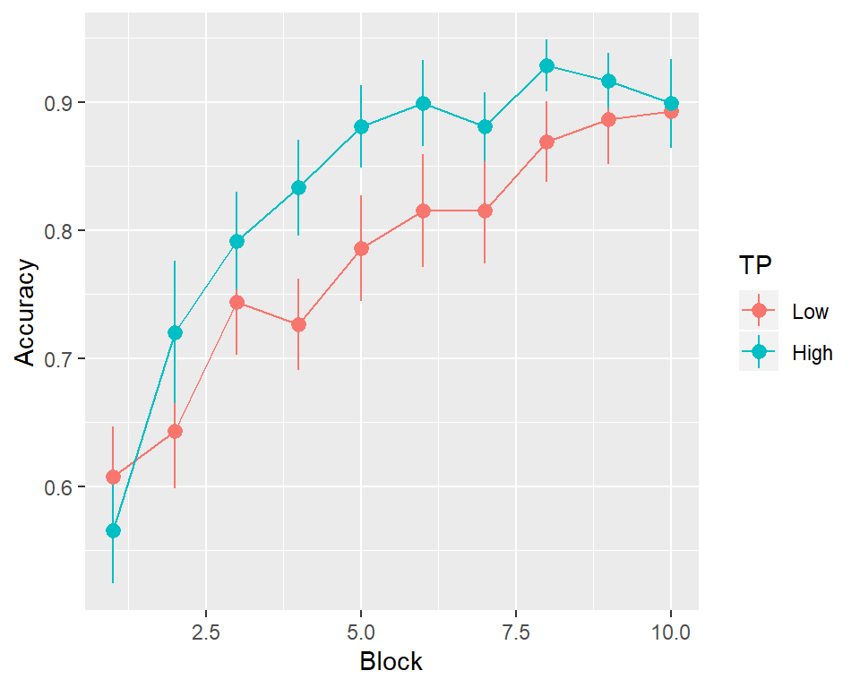

```r
ggplot(WordLearnEx, aes(Block, Accuracy, color=TP)) +
  stat_summary(fun.data=mean_se, geom="pointrange") +
  stat_summary(fun.y=mean, geom="line")
```

# Example: Prepare for GCA

Create 2nd-order orthogonal polynomial

```r
WordLearn.gca <- code_poly(WordLearnEx, predictor="Block", poly.order=2, orthogonal=TRUE)
```

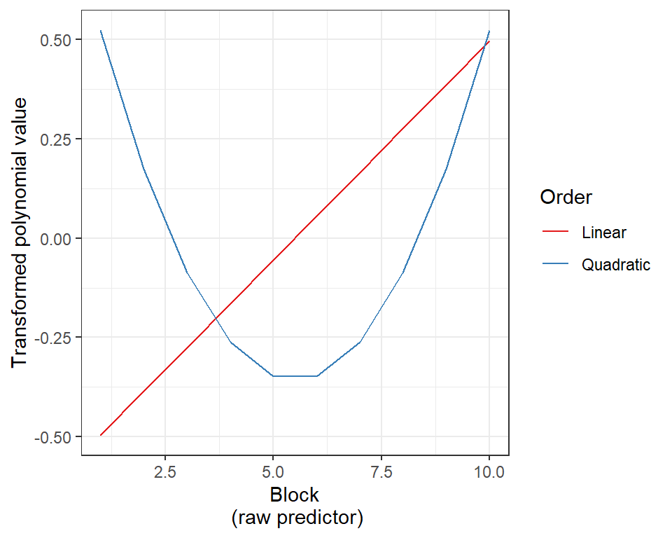

```r
summary(WordLearn.gca)
```

```
##     Subject       TP          Block         Accuracy      Block.Index
##  244    : 10   Low :280   Min.   : 1.0   Min.   :0.000   Min.   : 1.0
##  253    : 10   High:280   1st Qu.: 3.0   1st Qu.:0.667   1st Qu.: 3.0
##  302    : 10              Median : 5.5   Median :0.833   Median : 5.5
##  303    : 10              Mean   : 5.5   Mean   :0.805   Mean   : 5.5
##  305    : 10              3rd Qu.: 8.0   3rd Qu.:1.000   3rd Qu.: 8.0
##  306    : 10              Max.   :10.0   Max.   :1.000   Max.   :10.0
##  (Other):500
##      poly1            poly2
##  Min.   :-0.495   Min.   :-0.348
##  1st Qu.:-0.275   1st Qu.:-0.261
##  Median : 0.000   Median :-0.087
##  Mean   : 0.000   Mean   : 0.000
##  3rd Qu.: 0.275   3rd Qu.: 0.174
##  Max.   : 0.495   Max.   : 0.522
##
```

# Example: Fit the models

```r
library(lme4)
#fit base model
m.base <- lmer(Accuracy ~ (poly1+poly2) + (poly1+poly2 | Subject),
               data=WordLearn.gca, REML=F)
#add effect of TP on intercept
m.0 <- lmer(Accuracy ~ (poly1+poly2) + TP + (poly1+poly2 | Subject),
            data=WordLearn.gca, REML=F)
#add effect on slope
m.1 <- lmer(Accuracy ~ (poly1+poly2) + TP + TP:poly1 + (poly1+poly2 | Subject),
            data=WordLearn.gca, REML=F)
#add effect on quadratic
m.2 <- lmer(Accuracy ~ (poly1+poly2)*TP + (poly1+poly2 | Subject),
            data=WordLearn.gca, REML=F)
```

# Example: Compare the model fits

```r
anova(m.base, m.0, m.1, m.2)
```

```
## Data: WordLearn.gca
## Models:
## m.base: Accuracy ~ (poly1 + poly2) + (poly1 + poly2 | Subject)
## m.0: Accuracy ~ (poly1 + poly2) + TP + (poly1 + poly2 | Subject)
## m.1: Accuracy ~ (poly1 + poly2) + TP + TP:poly1 + (poly1 + poly2 |
## m.1:     Subject)
## m.2: Accuracy ~ (poly1 + poly2) * TP + (poly1 + poly2 | Subject)
##        Df  AIC  BIC logLik deviance Chisq Chi Df Pr(>Chisq)
## m.base 10 -331 -288    175     -351
## m.0    11 -330 -283    176     -352  1.55      1      0.213
## m.1    12 -329 -277    176     -353  0.36      1      0.550
## m.2    13 -333 -276    179     -359  5.95      1      0.015 *
## ---
## Signif. codes:  0 '***' 0.001 '**' 0.01 '*' 0.05 '.' 0.1 ' ' 1
```

# Example: Parameter estimates with p-values

```r
get_pvalues(m.2)
```

```
##               Estimate Std..Error  t.value  p.normal p.normal.star
## (Intercept)   0.778525    0.02173 35.82968 0.000e+00           ***
## poly1         0.286315    0.03779  7.57631 3.553e-14           ***
## poly2        -0.050849    0.03319 -1.53223 1.255e-01
## TPHigh        0.052961    0.03073  1.72349 8.480e-02             .
## poly1:TPHigh  0.001075    0.05344  0.02012 9.839e-01
## poly2:TPHigh -0.116455    0.04693 -2.48132 1.309e-02             *
```

# Example: Plot the model fit

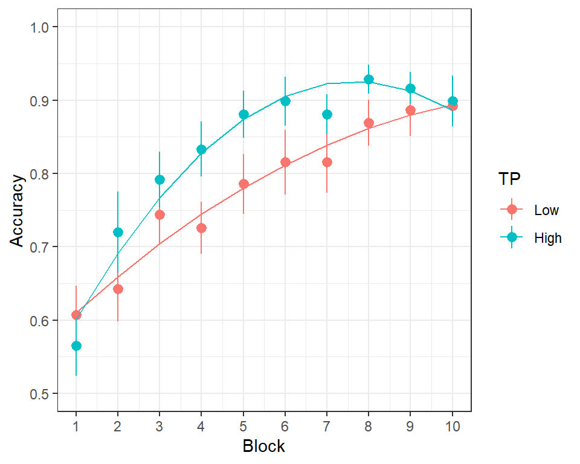

```r
ggplot(WordLearn.gca, aes(Block, Accuracy, color=TP)) +
  stat_summary(fun.data=mean_se, geom="pointrange") +
  stat_summary(aes(y=fitted(m.2)), fun.y=mean, geom="line") +
  theme_bw() + expand_limits(y=c(0.5, 1)) + scale_x_continuous(breaks = 1:10)
```

# Exercise 2

`CP` (d’ peak at category boundary): Compare categorical perception along spectral vs. temporal dimensions using second-order orthogonal polynomials.

- Plot the observed data
- (Why are orthogonal polynomials more useful for these data?)
- Prep the data for GCA
- Fit the GCA model(s)
- Interpret the results:
  - Which terms show significant effects of experimental factors?
  - To what extent do model comparisons and the parameter-specific p-values yield the same results?
- Plot observed and model fit data